## Title

Respiratory microbiome disruption and risk for ventilator-associated lower respiratory tract infection

## Abbreviated Title

MDI Stability and Predictive Utility

## Authors

James J. Harrigan, MD, PharmD (1); Hatem Abdallah (1); Erik L. Clarke, PhD (2); Arman Oganisian, MS (2); Jason A. Roy, PhD (4); Ebbing Lautenbach, MD, MPH, MS (1,2); Emily Reesey, MS (2); Magda Wernovsky (1); Pam Tolomeo, MPH (2); Zygmunt Morawski (5); Jerry Jacob, MD, MS (1,5); Michael A. Grippi, MD (3,5); Brendan J. Kelly, MD, MS (1,2)

## Affiliations

1 - Division of Infectious Diseases, Department of Medicine;  
2 - Department of Biostatistics, Epidemiology, and Informatics;  
3 - Division of Pulmonary, Allergy, and Critical Care, Department of Medicine, Perelman School of Medicine, University of Pennsylvania, Philadelphia, PA;  
4 - Department of Biostatistics and Epidemiology, Rutgers School of Public Health, Ruthers University, Piscataway, NJ;  
5 - Good Shepherd Penn-Partners Specialty Hospital, Philadelphia, PA

## Corresponding Author Contact

Brendan J. Kelly, MD, MS - brendank@pennmedicine.upenn.edu

## Authors’ Contributions

JJH - analysis, manuscript;  
HA - analysis, manuscript;  
ELC - analysis, manuscript;  
AO - analysis, manuscript;  
JAR - analysis, manuscript;  
EL - study design, manuscript;  
ER - specimen process, manuscript;  
MW - study enrollment, specimen processing, data collection, manuscript;  
PT - study enrollment, manuscript;  
ZM - study enrollment, manuscript;  
JJ - study enrollment, manuscript;  
MAG - study enrollment, manuscript;  
BJK - study design, data analysis, manuscript

## Disclosures

The authors report no relevant disclosures.

## Data Availability

Processed clinical and microbiome data, as well as analysis scripts and model code are available at github.com/bjklab. Raw 16S rRNA gene sequence data have been made publicly available at the National Center for Biotechnology Information’s Sequence Read Archive (NCBI SRA) with BioProject ID: PRJNA529220.

## Keywords

microbiome, ventilator-associated pneumonia, mechanical ventilation, long-term acute care

### Acknowledgements:

This study was funded by Centers for Disease Control and Prevention (CDC) contract awards (BAA 200-2016-91964 and 200-2018-02919). BJK is supported by the National Institute for Allergy and Infectious Diseases (K23 AI121485 and L30 AI120149). This research was also supported by a CDC Cooperative Agreement FOA#CK16-004-Epicenters for the Prevention of Healthcare Associated Infections.

## Manuscript

### Abstract

- **Background**: Ventilator-associated lower respiratory tract infection (VA-LRTI) is a common among critically ill patients and has been associated with increased morbidity and mortality. In acute critical illness, respiratory microbiome disruption indices (MDIs) have been shown to predict risk for VA-LRTI, but their utility beyond the first days of critical illness is unknown. We sought to characterize how MDIs previously shown to predict VA-LRTI at initiation of mechanical ventilation change with prolonged mechanical ventilation, and if they remain associated with VA-LRTI risk.
- **Methods**: We developed a cohort of 83 subjects admitted to a long-term acute care hospital due to their prolonged dependence on mechanical ventilation; performed dense, longitudinal sampling of the lower respiratory tract, collecting 1066 specimens; and characterized the lower respiratory microbiome by 16S rRNA sequencing as well as total bacterial abundance by 16S rRNA qPCR.
- **Results**: Cross-sectional MDIs, including low Shannon diversity and high total bacterial abundance, were associated with risk for VA-LRTI, but the associations had wide posterior credible intervals. Persistent lower respiratory microbiome disruption showed a more robust association with VA-LRTI risk, with each day of (base e) Shannon diversity < 2.0 associated with a VA-LRTI odds ratio of 1.36 (95% credible interval 1.10 to 1.72). The observed association was consistent across multiple clinical definitions of VA-LRTI.
- **Conclusions**: Cross-sectional MDIs have limited ability to discriminate VA-LRTI risk during prolonged mechanical ventilation, but persistent lower respiratory tract microbiome disruption, best characterized by consecutive days with low Shannon diversity, may identify a population at high risk for infection and may help target infection prevention interventions.

### Introduction:

Alterations in lower respiratory tract microbial community structure and membership have been found to be associated with risk for ventilator-associated lower respiratory tract infection (VA-LRTI) among critically ill subjects dependent on mechanical ventilation [1–4].

Approximately 15% (9-27%) of critically ill patients receive antibiotics for VA-LRTI. VA-LRTI increases the duration of critical illness and mechanical ventilation. Some studies suggest that VA-LRTI patients have as much as two-fold increased mortality relative to patients dependent on mechanical ventilation who do not develop LRTI [5–9]. Microbiome disruption indices (MDIs), which quantify the degree of perturbation in the respiratory microbial community, may permit early recognition, intervention, and prevention of VA-LRTI, thus alleviating associated morbidity and mortality [10].

To date, studies of respiratory microbiome disruption and VA-LRTI have focused on subjects with acute critical illness, and respiratory microbiome measures have typically been performed around the time of intubation and mechanical ventilation onset [3,11]. The respiratory microbiome disruption observed during this period may reflect true ventilator-associated infection, or it may reflect incipient pneumonia that contributed to the incident respiratory failure and critical illness [12,13]. However, prolonged mechanical ventilation has itself been shown to be associated with respiratory microbiome disruption even in the absence of infection [1], and the utility of microbiome disruption as a marker for infection risk later in critical illness remains poorly understood.

We sought to define the stability and predictive utility of three MDIs during prolonged critical illness. We enrolled 83 subjects and collected 1066 longitudinal respiratory tract samples to understand how (1) bacterial community diversity, (2) dominance of the lower respiratory tract bacterial community by a single taxon, and (3) total bacterial abundance relate to risk for VA-LRTI. Below we report the results of our investigation.

### Materials and Methods:

- **Study Design and Setting**: To understand how respiratory microbiome disruption impacts risk for VA-LRTI, we performed a prospective cohort study, enrolling subjects admitted to a long-term acute care hospital (LTACH) affiliated with the University of Pennsylvania, in Philadelphia, PA, USA. Initial endotracheal (ET) specimens were obtained at enrollment, and specimen collection was repeated at 24- to 72-hour intervals thereafter until mechanical ventilation was discontinued or 30 days elapsed. Informed consent was obtained from subjects or their surrogates. The protocols were reviewed and approved by the University of Pennsylvania IRB (protocol #826629).
- **Study Population**: Subjects were eligible for inclusion with (1) age >= 18 years, (2) dependence on mechanical ventilation, and (3) admission to LTACH with goal of ventilator weaning. Tracheostomy had been performed on all subjects prior to LTACH admission. Duration of critical care and mechanical ventilation prior to LTACH admission varied across subjects.
- **Clinical Data Collection**: Using the Penn Data Store, a repository of clinical data compiled from the electronic medical record, we measured subject demographics, including age, sex, race, and ethnicity; underlying medical diagnoses; antibiotic exposure prior to enrollment; and baseline laboratory values. Clinical respiratory culture data, antibiotic administration data, and vital sign data were captured for 30-days from subject enrollment.
- **Specimen Collection, Data Collection, and Processing**: ET specimens were collected during routine daily suctioning of the subjects’ tracheal tubes. During suctioning, 1-5mL of sterile saline were introduced as a sterile catheter was advanced into the mid-trachea and then suctioned back into a Lukens trap. ET specimens were stored immediately on ice and transferred to −80°C storage within 2 hours of collection. After DNA extraction (QIAGEN DNeasy Powersoil) and amplification of the V1-V2 16S ribosomal RNA (rRNA) gene hypervariable region (27F - 338R) as previously described [1], we performed paired-end 250bp sequencing (Illumina HiSeq), sequence demultiplexing and alignment (QIIME2), sequence denoising and amplicon sequence-variant (ASV) binning (DADA2 with trimming to bases 13-200). ASVs were used to permit granular analysis and to improve compatibility across studies [14,15]. Genus-level taxonomic assignments were performed by QIIME 2’s default classifier (Project SILVA_132_SSURef_Nr99 database) [16,17]. 16S rRNA gene quantitative PCR (qPCR) was performed using the same amplicon [18]. A total of 1066 respiratory tract specimens were collected from 83 subjects. An analysis of the intitial specimen from each subject was previously presented as an abstract[19], but the longitudinal data has not been previously presented.
- **Definition of Exposures**: At each timepoint, we measured bacterial community as the Shannon diversity (base e) of the bacterial community defined by 16S rRNA gene ASVs. We defined dominance of the lower respiratory tract bacterial community as the proportional abundance of the most abundant ASV; communities were considered dominated by a single taxon if maximum proportional abundance exceeded 50%. We defined the total bacterial abundance as the the 16S rRNA gene copy number per mL of endotracheal aspirate.
- **Definition of Outcome**: A challenge to understanding the relationship between respiratory microbiome disruption and infection is the absence of a gold standard definition for infection [12,20]. We defined VA-LRTI by three criteria: (1) the order of a clinical respiratory culture to indicate suspicion for respiratory infection, (2) identification and reporting of a bacterial growth from culture by the clinical microbiology lab, and (3) vital or laboratory signs of infection (white blood cell (WBC) count outside normal range, or fever). As a sensitivity analysis, we also evaluated alternate definitions of VA-LRTI: (a) VA-LRTI defined by ordering a respiratory culture alone, or (b) respiratory culture order and bacterial growth with concomitant signs of infection (as above) and initiation or alteration of antibiotic prescription within 48 hours of culture collection.
- **Statistical Methods**: Data were organized using R statistical software version 4.0.3 [21], and plots generated using the “ggplot2” package [22]. Potential confounders were compared between exposure groups using Wilcoxon rank-sum testing (continuous variables) and Fisher’s exact test (categorical variables). Bayesian mixed effects regression models were applied to understand the relationship between MDIs and VA-LRTI, incorporating random effects for subjects to account for the longitudinal nature of the data. For all analyses related to VA-LRTI, data were censored at the time of first VA-LRTI diagnosis. No imputation was performed for cross-sectional analyses. For the analysis of microbiome disruption persistence, if microbiome specimens had not been obtained on the day of VA-LRTI, we imputed the MDI on that day as the last recorded value. 6.3% of values were imputed for this analysis. For comparison, we also analyzed models with no imputation and with all missing values imputed in the same manner. Models were fit using Stan Hamiltonian Monte Carlo (HMC) version 2.25 via the “brms” package [23–25]. After prior predictive checks, models were fit with 4 chains of 1000 iterations, confirmed with HMC diagnostics (no divergent iterations, Rhat statistic < 1.1 for all parameters, and E-BFMI > 0.2), and by examining the posterior distributions [26,27]. Point estimates of parameters (posterior median) are presented, with 95% posterior credible intervals (95%CI). Models were evaluated using leave-one-out cross-validation and the widely applicable information criterion; model comparisons were made on the expected log predictive density (ELPD) for new data [28].
- **Power and Sample Size**: Based on the median duration of LTACH admission, the observed incidence of VA-LRTI at the study site, and our prior study of respiratory microbiome disruption among mechanically ventilated patients [1], we estimated that 70 subjects would yield posterior precision to detect an MDI-associated odds ratio of 1.4 with type S error < 0.05 [29–31]. We exceeded the target enrollment with 83 subjects.
- **Availability of Data**: Sequence data is publicly available on the National Center for Biotechnology Information’s Sequence Read Archive (NCBI SRA) with BioProject ID PRJNA529220. Model code, as well as code used to produce the manuscript and figures, is available at github.com/bjklab.



### Discussion:

We enrolled a cohort of subjects with prolonged dependence on mechanical ventilation at the time of their LTACH admission in order to understand how MDIs previously shown to predict VA-LRTI at initiation of mechanical ventilation change with prolonged mechanical ventilation, and how strongly they remain associated with VA-LRTI risk. Consistent with preliminary studies [1], we found that lower respiratory tract bacterial community diversity is reduced among subjects requiring prolonged mechanical ventilation relative to newly intubated patients [3,4,11], but median diversity remained stable over the course of long-term care. In this cohort, cross-sectional MDIs were only weakly associated with risk for VA-LRTI. Lower Shannon diversity and high total bacterial burden in the respiratory tract (log 16S rRNA gene copies) were both associated with increased risk for VA-LRTI, but the 95% posterior credible intervals of their associations included a null effect. Even models incorporating multiple cross-sectional MDIs showed poor predictive performance for VA-LRTI. It was only persistent disruption of the lower respiratory tract bacterial community that more reliably discriminated risk for VA-LRTI, and low bacterial community diversity (base e Shannon index < 2.0) performed best among the MDIs with VA-LRTI odds ratio odds ratio 1.36 (95%CI 1.10 to 1.72) per day of persistent microbiome disruption. The association between low Shannon diversity and VA-LRTI risk was consistent across multiple definitions of VA-LRTI.

The finding that persistent lower respiratory tract microbiome disruption is significantly associated with VA-LRTI risk, even in an LTACH population with reduced baseline diversity, is significant for several reasons. First, our findings suggest that respiratory tract microbiome disruption may be a valuable biomarker, not only in acute critical illness [3,4,11], but also during prolonged critical illness and long-term mechanical ventilation. Second, our findings suggest that factors contributing to low respiratory tract diversity, including antibiotic exposure and pulmonary toilet practices, may contribute to the mechanism by which VA-LRTI occurs. These findings may inform and help target infection control and antibiotic stewardship practices for mechanically-ventilated patients as metagenomic profiling of the respiratory microbiome enters the clinical laboratory [32]. Third, the better discrimination of VA-LRTI risk observed with Shannon diversity, compared to maximum ASV proportional abundance (i.e., bacterial community dominance) and total bacterial abundance (copies of 16S rRNA per mL of sputum), may guide the implementation of future MDI-surveillance interventions [10].

Several weaknesses of our study must be noted. First, there is no gold standard for VA-LRTI, and we relied upon clinical features to define VA-LRTI in our cohort, scrutinizing our findings with a sensitivity analysis that compared alternative VA-LRTI definitions. We could not include chest radiography as a clinical feature defining VA-LRTI because few radiographs were performed in our cohort. Second, our cohort was recruited from a single LTACH site, though at the time of enrollment patients had been received in transfer from multiple referring hospitals. These weaknesses may limit the external validity of our findings. Third, we evaluated MDIs with univariable regression because we were motivated to evaluate their utility as biomarkers for infection risk, and we performed only a limited analysis of multivariable models. Other model structures (e.g., tree models) that incorporate multiple MDIs may improve predictive utility. Our key finding – that persistent respiratory tract bacterial community disruption is more informative than cross-sectional MDIs – is based on a simple model structure, with room for further improvement. Our models of persistent microbiome disruption used the number of consecutive days of disruption to predict VA-LRTI, relying on simple, dichotomized definitions of disruption in order to classify each day. Better methods are needed to quantify the degree of microbiome disruption over time.

We have demonstrated that persistent lower respiratory tract bacterial community disruption is associated with increased risk for VA-LRTI, even after prolonged critical illness and mechanical ventilation, and even among subjects with much lower baseline bacterial community diversity than observed during acute critical illness. The persistence of low Shannon diversity best discriminated risk for VA-LRTI in our cohort. Future studies must elucidate healthcare practices that drive persistent lower respiratory microbiome disruption and interventions that can correct it or mitigate its impact. If we are to realize the potential for MDIs to improve clinical care, future studies must also focus on how informative features of the respiratory microbiome can be measured rapidly and continually during critical illness.

### Tables:

#### Table 1:

| **Subject Characteristics** | **Subject Category & Number** **All Subjects**, N = 83<sup>1</sup> | **Subject Category & Number** **High Admission Shannon Diversity**, N = 41<sup>1</sup> | **Subject Category & Number** **Low Admission Shannon Diversity**, N = 42<sup>1</sup> | **p-value**<sup>2</sup> |  |
| --- | --- | --- | --- | --- | --- |
| Primary Exposure and Enrollment Duration |  |  |  |  |  |
| Admission Shannon Diversity (base e) | 2.00 (0.90, 2.91) | 2.91 (2.49, 3.60) | 0.90 (0.17, 1.39) |  | <0.001 |
| Sampling Duration (days) | 21 (6, 42) | 17 (5, 35) | 24 (14, 42) | 0.25 |  |
| Demographics and Medical Comorbidities |  |  |  |  |  |
| Age | 69 (61, 74) | 68 (60, 74) | 70 (61, 74) | 0.62 |  |
| Gender |  |  |  | 0.059 |  |
| Female | 37 (45%) | 14 (34%) | 23 (55%) |  |  |
| Male | 46 (55%) | 27 (66%) | 19 (45%) |  |  |
| Race |  |  |  | 0.94 |  |
| Asian | 1 (1.2%) | 0 (0%) | 1 (2.4%) |  |  |
| Black | 26 (31%) | 13 (32%) | 13 (31%) |  |  |
| Other | 1 (1.2%) | 0 (0%) | 1 (2.4%) |  |  |
| Unknown | 3 (3.6%) | 1 (2.4%) | 2 (4.8%) |  |  |
| White | 52 (63%) | 27 (66%) | 25 (60%) |  |  |
| Days Mechanical Ventilation Prior to LTACH Admission | 38 (25, 60) | 30 (23, 56) | 47 (31, 61) | 0.15 |  |
| Days Tracheostomy Prior to LTACH Admission | 24 (11, 45) | 16 (10, 40) | 28 (12, 50) | 0.16 |  |
| Pneumonia Noted Prior to LTACH Admission | 26 (31%) | 10 (24%) | 16 (38%) | 0.18 |  |
| COPD | 10 (12%) | 5 (12%) | 5 (12%) | >0.99 |  |
| Asthma | 7 (8.4%) | 2 (4.9%) | 5 (12%) | 0.43 |  |
| ILD | 2 (2.4%) | 1 (2.4%) | 1 (2.4%) | >0.99 |  |
| Lymphoma/Leukemia | 3 (3.6%) | 2 (4.9%) | 1 (2.4%) | 0.62 |  |
| DM | 33 (40%) | 13 (32%) | 20 (48%) | 0.14 |  |
| CHF | 39 (47%) | 18 (44%) | 21 (50%) | 0.58 |  |
| Cirrhosis | 6 (7.2%) | 2 (4.9%) | 4 (9.5%) | 0.68 |  |
| Admission Laboratory Values and Ventilator Settings |  |  |  |  |  |
| WBC | 11.1 (8.1, 13.6) | 11.4 (9.0, 13.8) | 11.0 (8.0, 13.1) | 0.63 |  |
| Cr | 0.93 (0.52, 1.58) | 0.80 (0.47, 1.62) | 1.06 (0.76, 1.54) | 0.25 |  |
| AST | 31 (19, 40) | 34 (21, 40) | 29 (16, 49) | 0.60 |  |
| ALT | 26 (16, 60) | 40 (17, 73) | 22 (14, 44) | 0.36 |  |
| FiO2 (%) | 40 (40, 40) | 40 (40, 40) | 40 (40, 40) | 0.45 |  |
| PEEP | 5.00 (5.00, 6.00) | 5.00 (5.00, 7.50) | 5.00 (5.00, 5.00) | 0.12 |  |
| Antibiotics Within 7 Days Prior to Admission |  |  |  |  |  |
| Vancomycin (IV) | 14 (17%) | 8 (20%) | 6 (14%) | 0.52 |  |
| Metronidazole | 3 (3.6%) | 1 (2.4%) | 2 (4.8%) | >0.99 |  |
| Linezolid | 2 (2.4%) | 0 (0%) | 2 (4.8%) | 0.49 |  |
| Daptomycin | 4 (4.8%) | 1 (2.4%) | 3 (7.1%) | 0.62 |  |
| Cefazolin | 3 (3.6%) | 0 (0%) | 3 (7.1%) | 0.24 |  |
| Piperacillin-tazobactam | 4 (4.8%) | 4 (9.8%) | 0 (0%) | 0.055 |  |
| Cefepime | 11 (13%) | 7 (17%) | 4 (9.5%) | 0.31 |  |
| Meropenem | 4 (4.8%) | 1 (2.4%) | 3 (7.1%) | 0.62 |  |

<sup>*1*</sup> Median (IQR); n (%) <sup>*2*</sup> Wilcoxon rank sum test; Wilcoxon rank sum exact test; Pearson's Chi-squared test; Fisher's exact test

**Table 1: Subject characteristics.** Subject demographics, laboratory values at day of enrollment, medical comorbidities, and recent (within 7 days) pre-enrollment antibiotic exposures are presented. For categorical variables, counts and proportions are given; for continuous variables, medians and interquartile ranges are given. Subjects are described in aggregate and grouped by above or below median lower respiratory tract Shannon diversity at the time of enrollment. To identify variables associated with initial lower respiratory tract Shannon diversity, categorical values are compared with Fisher’s exact test, and continuous variables are compared with Wilcoxon rank-sum tests. (COPD: chronic obstructive pulmonary disease; ILD: interstitial lung disease; DM: diabetes mellitus; CHF: congestive heart failure; WBC: white blood cell count; Cr: serum creatinine; AST: aspartate aminotransferase; ALT: alanine aminotransferase; FIO2: fraction of inspired oxygen; PEEP: positive end-expiratory pressure; IV: intravenous).

### Figures:

#### Figure 1:

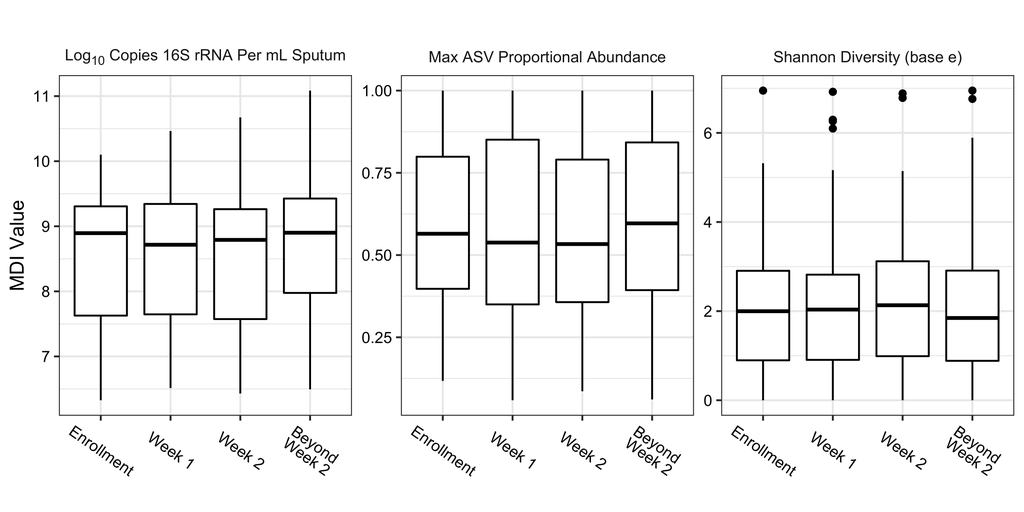

**Figure 1: Longitudinal stability of microbiome disruption indices during long-term acute care.** Boxplots show the distribution of MDI values at enrollment and over the duration of long-term mechanical ventilation, with median values shown as a thick horizontal bars, interquartile ranges (IQRs) shown as boxes, whiskers extending to 1.5 * IQR, and outliers depicted as points.

#### Figure 2:

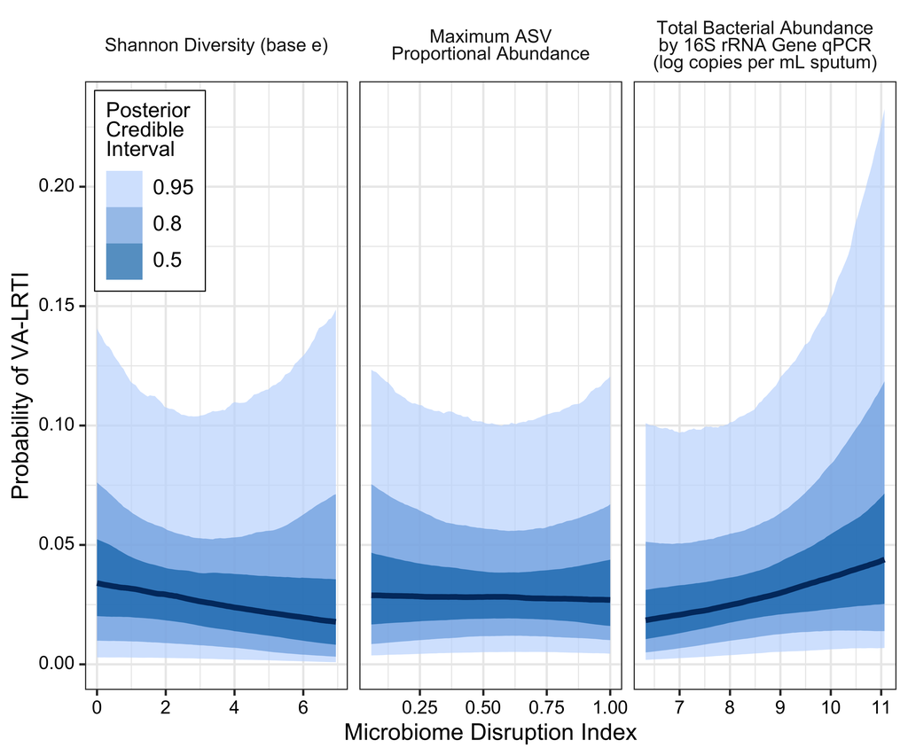

**Figure 2: Concurrent probability of VA-LRTI in relation to cross-sectional microbiome disruption indices.** The results of logistic regression models relating the daily risk of VA-LRTI to MDIs are shown, with the range of observed MDI values on the horizontal axis and the posterior probability of VA-LRTI on the vertical axis. The dark line indicates the posterior median, and the blue shading indicates a range of posterior credible intervals as shown.

#### Figure 3:

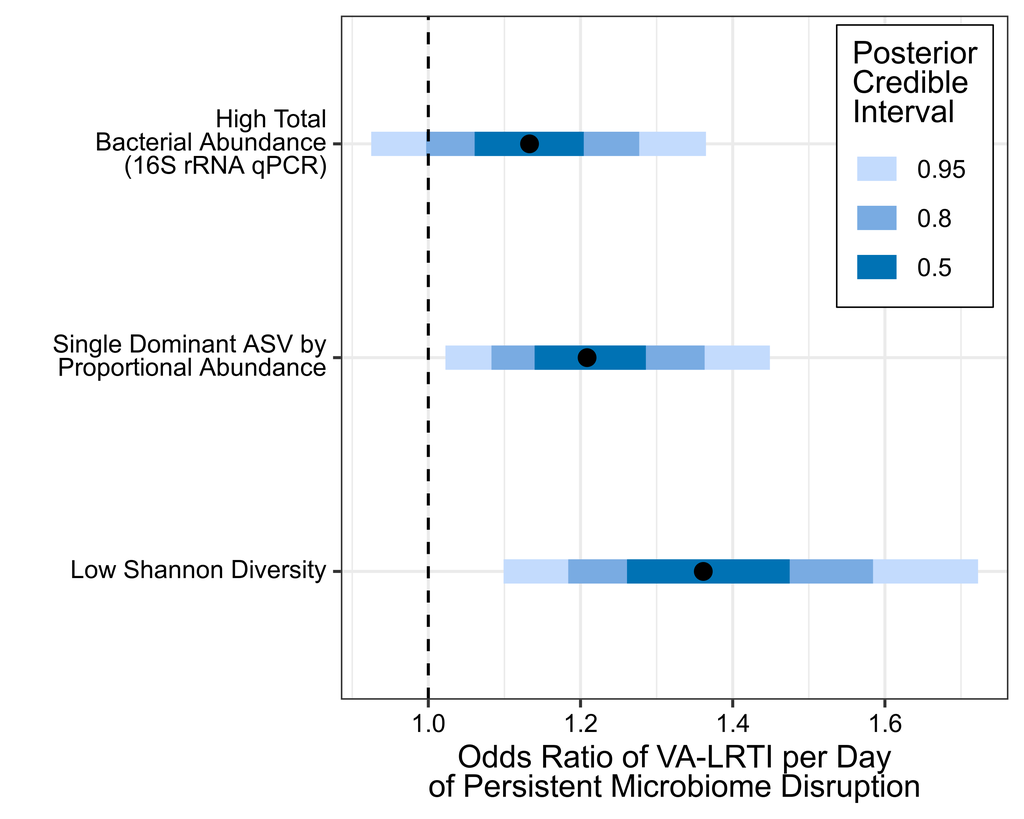

**Figure 3: Persistent respiratory microbiome disruption predicts VA-LRTI during long-term acute care.** The odds ratio of VA-LRTI associated with each 1-day increase in the persistence of respiratory bacterial microbiome disruption is shown, with persistent microbiome disruption defined as either low (below median) Shannon diversity, high (above 50%) maximum ASV proportional abundance, or high (above median) total bacterial abundance. The point indicates the posterior median, and the blue shading indicates a range of posterior credible intervals as shown.

### Supplemental Figures:

#### Supplemental Figure 1:

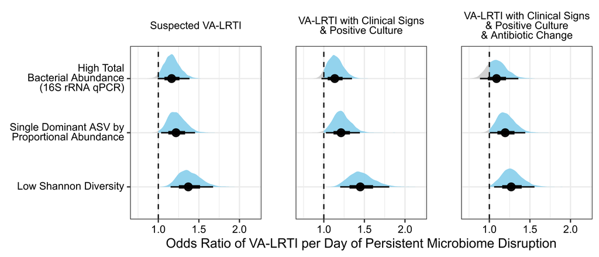

**Supplemental Figure 1: VA-LRTI risk associated with persistent microbiome disruption, depending on definition of VA-LRTI.** We evaluated the odds ratio of VA-LRTI associated with each 1-day increase in the persistence of respiratory bacterial microbiome disruption and compared the results across three VA-LRTI outcome definitions, for each of the three measured MDIs. The black points, bars, and lines indicate the posterior median, 50%CI, and 95%CI intervals, respectively. The posterior distribution is depicted above the interval with the area supporting increased VA-LRTI risk shaded blue, and the area supporting decreased VA-LRTI risk shaded gray.

## References

1. Kelly BJ, Imai I, Bittinger K, et al. Composition and dynamics of the respiratory tract microbiome in intubated patients. Microbiome **2016**; 4:7. Available at: http://dx.doi.org/10.1186/s40168-016-0151-8.

2. Kitsios GD, Fitch A, Manatakis DV, et al. Respiratory microbiome profiling for etiologic diagnosis of pneumonia in mechanically ventilated patients. Frontiers in microbiology **2018**; 9:1413. Available at: http://dx.doi.org/10.3389/fmicb.2018.01413.

3. Langelier C, Kalantar KL, Moazed F, et al. Integrating host response and unbiased microbe detection for lower respiratory tract infection diagnosis in critically ill adults. Proceedings of the National Academy of Sciences of the United States of America **2018**; 115:E12353–E12362. Available at: http://dx.doi.org/10.1073/pnas.1809700115.

4. Dickson RP, Schultz MJ, Poll T van der, et al. Lung microbiota predict clinical outcomes in critically ill patients. American journal of respiratory and critical care medicine **2020**; 201:555–563. Available at: http://dx.doi.org/10.1164/rccm.201907-1487OC.

5. Chastre J, Fagon J-Y. Diagnosis of ventilator-associated pneumonia. The New England journal of medicine **2007**; 356:1469; author reply 1470–1. Available at: http://dx.doi.org/10.1056/NEJMc076017.

6. Klompas M. Does this patient have ventilator-associated pneumonia? JAMA: the journal of the American Medical Association **2007**; 297:1583–1593. Available at: http://dx.doi.org/10.1001/jama.297.14.1583.

7. Klompas M. Complications of mechanical ventilation–the CDC’s new surveillance paradigm. The New England journal of medicine **2013**; 368:1472–1475. Available at: http://dx.doi.org/10.1056/NEJMp1300633.

8. Rello J, Quintana E, Ausina V, et al. Incidence, etiology, and outcome of nosocomial pneumonia in mechanically ventilated patients. Chest **1991**; 100:439–444. Available at: http://dx.doi.org/10.1378/chest.100.2.439.

9. Vincent J-L, Rello J, Marshall J, et al. International study of the prevalence and outcomes of infection in intensive care units. JAMA: the journal of the American Medical Association **2009**; 302:2323–2329. Available at: http://dx.doi.org/10.1001/jama.2009.1754.

10. Halpin AL, McDonald LC. Editorial commentary: The dawning of microbiome remediation for addressing antibiotic resistance. Clinical infectious diseases: an official publication of the Infectious Diseases Society of America **2016**; 62:1487–1488. Available at: http://dx.doi.org/10.1093/cid/ciw187.

11. Kitsios GD, Yang H, Yang L, et al. Respiratory tract dysbiosis is associated with worse outcomes in Mechanically-Ventilated patients. American journal of respiratory and critical care medicine **2020**; Available at: http://dx.doi.org/10.1164/rccm.201912-2441OC.

12. Chanderraj R, Dickson RP. Rethinking pneumonia: A paradigm shift with practical utility. Proceedings of the National Academy of Sciences of the United States of America **2018**; 115:13148–13150. Available at: http://dx.doi.org/10.1073/pnas.1819024116.

13. Dickson RP, Erb-Downward JR, Huffnagle GB. Towards an ecology of the lung: New conceptual models of pulmonary microbiology and pneumonia pathogenesis. The Lancet Respiratory medicine **2014**; 2:238–246. Available at: http://dx.doi.org/10.1016/S2213-2600(14)70028-1.

14. Bolyen E, Rideout JR, Dillon MR, et al. Reproducible, interactive, scalable and extensible microbiome data science using QIIME 2. Nature biotechnology **2019**; 37:852–857. Available at: http://dx.doi.org/10.1038/s41587-019-0209-9.

15. Callahan BJ, McMurdie PJ, Rosen MJ, Han AW, Johnson AJA, Holmes SP. DADA2: High-resolution sample inference from illumina amplicon data. Nature methods **2016**; 13:581–583. Available at: http://dx.doi.org/10.1038/nmeth.3869.

16. Munoz R, Yarza P, Ludwig W, et al. Release LTPs104 of the All-Species Living Tree. Systematic and applied microbiology **2011**; 34:169–170. Available at: http://dx.doi.org/10.1016/j.syapm.2011.03.001.

17. Yarza P, Richter M, Peplies J, et al. The All-Species living tree project: A 16S rRNA-based phylogenetic tree of all sequenced type strains. Systematic and applied microbiology **2008**; 31:241–250. Available at: http://dx.doi.org/10.1016/j.syapm.2008.07.001.

18. Lauder AP, Roche AM, Sherrill-Mix S, et al. Comparison of placenta samples with contamination controls does not provide evidence for a distinct placenta microbiota. Microbiome **2016**; 4:29. Available at: http://dx.doi.org/10.1186/s40168-016-0172-3.

19. Clarke E, Chiotos KN, Harrigan J, et al. Comparison of respiratory microbiome disruption indices to predict VAP and VAE risk at LTACH admission. Infection control and hospital epidemiology: the official journal of the Society of Hospital Epidemiologists of America **2020**; 41:s179–s180. Available at: https://www.cambridge.org/core/services/aop-cambridge-core/content/view/0181FB9FBA3D2DB0F35A9304743BF75F/S0899823X20007114a.pdf/div-class-title-comparison-of-respiratory-microbiome-disruption-indices-to-predict-vap-and-vae-risk-at-ltach-admission-div.pdf.

20. Dickson RP. Kudzu and sleeper cells: The varied ecology of respiratory infections. The European respiratory journal: official journal of the European Society for Clinical Respiratory Physiology **2018**; 52. Available at: http://dx.doi.org/10.1183/13993003.01607-2018.

21. R Core Team. R: A language and environment for statistical computing. 2018; Available at: https://www.R-project.org/.

22. Wickham H. Ggplot2: Elegant graphics for data analysis. 1st ed. 2009. Corr. 3rd printing 2010 edition. Springer International Publishing, 2016. Available at: https://play.google.com/store/books/details?id=RTMFswEACAAJ.

23. Bürkner P-C. Brms: An R package for bayesian multilevel models using stan. Journal of Statistical Software, Articles **2017**; 80:1–28. Available at: https://www.jstatsoft.org/v080/i01.

24. Carpenter B, Gelman A, Hoffman MD, et al. Stan: A probabilistic programming language. Journal of statistical software **2017**; 76:1–32. Available at: https://www.jstatsoft.org/v076/i01.

25. McElreath R. Statistical rethinking: A bayesian course with examples in R and stan. 1 edition. CRC Press/Taylor & Francis Group, 2016. Available at: https://play.google.com/store/books/details?id=d7fCsgEACAAJ.

26. Gabry J, Simpson D, Vehtari A, Betancourt M, Gelman A. Visualization in bayesian workflow. Journal of the Royal Statistical Society Series A, **2019**; 182:389–402. Available at: https://onlinelibrary.wiley.com/doi/abs/10.1111/rssa.12378.

27. Gelman A, Vehtari A, Simpson D, et al. Bayesian workflow. **2020**; Available at: http://arxiv.org/abs/2011.01808.

28. Vehtari A, Gelman A, Gabry J. Practical bayesian model evaluation using leave-one-out cross-validation and WAIC. Statistics and computing **2017**; 27:1413–1432. Available at: https://doi.org/10.1007/s11222-016-9696-4.

29. Gelman A, Tuerlinckx F. Type S error rates for classical and bayesian single and multiple comparison procedures. Computational statistics **2000**; 15:373–390. Available at: https://doi.org/10.1007/s001800000040.

30. Gelman A, Carlin J. Beyond power calculations: Assessing type S (sign) and type M (magnitude) errors. Perspectives on psychological science: a journal of the Association for Psychological Science **2014**; 9:641–651. Available at: http://dx.doi.org/10.1177/1745691614551642.

31. Rothman KJ, Greenland S. Planning study size based on precision rather than power. Epidemiology **2018**; 29:599–603. Available at: http://dx.doi.org/10.1097/EDE.0000000000000876.

32. Chiu CY, Miller SA. Clinical metagenomics. Nature reviews Genetics **2019**; 20:341–355. Available at: http://dx.doi.org/10.1038/s41576-019-0113-7.